# Elektronikktest ⚡

Løysingsforslag

Publisert

26. november 2024

# Oppgave 1 📖

1. Forklar **kort** hva som menes med følgende begreper:

   **Strøm**: Strøm er eit mål på kor mange elektriske ladningar (elektronar) som passerer gjennom ein leiar per tidsenhet. Eininga for strøm er ampere ($A$), der 1 ampere tilsvarar 1 coulomb per sekund.

   **Motstand**: Motstand er eigenskapen eit materiale eller ein komponent har til å motstå straumen av elektriske ladningar. Motstand reduserer straumen i ein krets. Eininga for motstand er ohm ($\Omega$).

   **Ohms lov**: Ohms lov beskriver sambandet mellom spenning ($U$), strøm ($I$) og motstand ($R$) i ein elektrisk krets, gitt ved formelen $U = I \cdot R$. Dette betyr at spenninga over ein motstand er lik straumen gjennom motstanden multiplisert med motstanden sin verdi.

# Oppgave 2 💡

I begge alternativa antar me at dioden er ideell med 0 i spenningsfall og motstand i rett retning.

#### 🟢 Alternativ 1

1. **Tegn et koblingsskjema** for en krets hvor et 9 V batteri er koblet i serie med en motstand på $220 \Omega$, en lysdiode og en parallellkobling. I parallellkoblingen skal hver grein ha en motstand på $560 \Omega$ og en lysdiode.

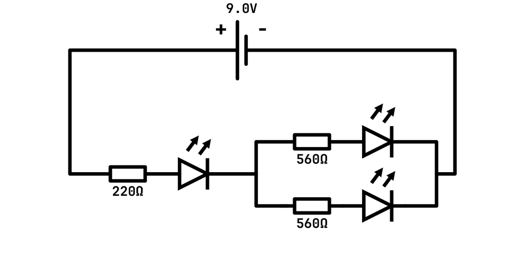

2. Gjør nødvendige beregninger for å bestemme
   1. resultantresistansen i parallellkoblingen og resultantresistansen i koblingen av alle komponentene

      Motstanden i kvar grein av parallellkoblinga er summen av motstanden og lysdioda. Sidan vi antar at spenningsfallet over lysdiodene er 0 V, og dei har ingen motstand, kan vi ignorere dei i motstandsberekninga. $R_{\text{motstand}} = 560 \Omega$.

      $$R_{\text{parallell}} = \left(\frac{1}{R_1} + \frac{1}{R_2}\right)^{-1} = \left(\frac{1}{560} + \frac{1}{560}\right)^{-1} = 280 \Omega$$

      Resultantresistansen for heile kretsen:

      $$R_{\text{total}} = 220 + 280 = 500 \Omega$$
   2. den totale strømmen gjennom kretsen

      Bruker Ohms lov.

      $$I_{\text{total}} = \frac{U_{\text{total}}}{R_{\text{total}}} = \frac{9 V}{500 \Omega} = 0.018 A = 18 mA$$
   3. greinstrømmene gjennom parallellkoblingen

      Finn spenninga over parallellkoplinga.

      $$U_{\text{parallell}} = I_{\text{total}} \cdot R_{\text{parallell}} = 0.018 A \cdot 280 \Omega = 5.04 V$$

      Finn straumen i kvar grein.

      $$I_{\text{grein}} = \frac{U_{\text{parallell}}}{R_{\text{motstand}}} = \frac{5.04 V}{560 \Omega} = 0.009 A = 9 mA$$

      Sidan motstandane i parallellkoblinga er like, vil straumen i kvar grein også vere lik.

      Me ser og at $2 \cdot I_{\text{grein}} = I_{\text{total}}$.

#### 🟥 Alternativ 2

**Tegn et koblingsskjema** for en krets hvor et $15 V$ batteri er koblet i serie med en motstand på $150 \Omega$, en lysdiode, og en parallellkobling. I parallellkoblingen er det tre greiner:

- Grein 1: En motstand på $330 \Omega$ i serie med en lysdiode.
- Grein 2: En parallellkobling som består av to motstander på $470 \Omega$ hver, koblet parallelt med hverandre.
- Grein 3: En motstand på $220 \Omega$ i serie med en parallellkobling av to motstander på $560 \Omega$ og $680 \Omega$.

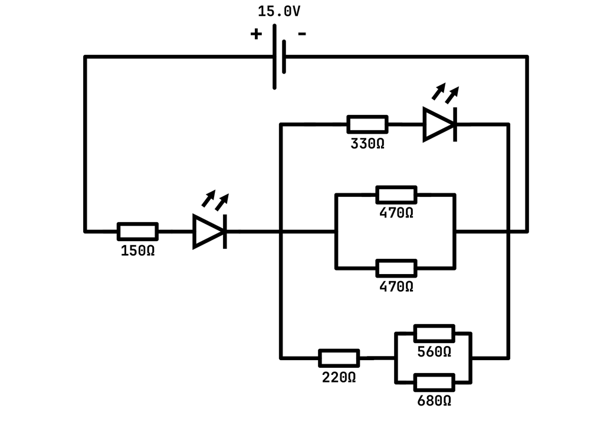

**Regn ut** strømmen som går gjennom hele kretsen.

Gjør beregninger og **vurder** om de ulike LED-ene vil tåle oppsettet slik det står.

**Dersom tid:** Foreslå eventuelle endringer og argumenter for disse endringene.

For å rekne ut straumen som går gjennom heile kretsen, kan me bruke Ohms lov. Då treng me å rekna ut den totale motstanden i kretsen først.

Startar med å rekna ut motstanden i kvar grein av parallellkoblinga.

**Grein 1**
$$R_{\text{grein1}} = 330 \Omega$$
sidan me går ut frå at spenningsfallet over lysdioden er 0 V.

**Grein 2**
$$R_{\text{grein2}} = \left(\frac{1}{470} + \frac{1}{470}\right)^{-1} = \left(\frac{2}{470} \right)^{-1} = 235 \Omega$$

**Grein 3**
$$R_{\text{grein3}} = 220 + \left(\frac{1}{560} + \frac{1}{680}\right)^{-1} = 220 + \left(\frac{31}{9520}\right)^{-1} \approx 220 + 307 = 527 \Omega$$

Vidare kan me rekna ut den totale motstanden i parallellkoblinga.

$$R_{\text{parallell}} = \left(\frac{1}{330} + \frac{1}{235} + \frac{1}{527}\right)^{-1} \approx 108.9 \Omega$$

Den totale motstanden i kretsen er då
$$R_{\text{total}} = 150 + 108.9 = 258.9 \Omega$$

Dermed kan me rekna ut straumen som går gjennom heile kretsen.

$$I_{\text{total}} = \frac{U_{\text{total}}}{R_{\text{total}}} = \frac{15 V}{258.9 \Omega} \approx 0.058 A = 58 mA$$

For å vurdere om lysdiodene vil tåle oppsettet, må me sjå på straumen som går gjennom dei.

Den første LEDen vil det gå $I_{\text{total}}$ gjennom, altså 58 mA. Lysdiodar tåler vanlegvis straum på rundt 20 mA, så denne vil mest truleg brennast ut.

Den andre LEDen går gjennom grein 1. Finn straumen i denne greina. Då treng me først å finne spenninga over parallellkoplinga.

$$U_{\text{parallell}} = I_{\text{total}} \cdot R_{\text{parallell}} = 0.058 A \cdot 108.9 \Omega \approx 6.32 V$$

Denne LEDen vil mest truleg tåle straumen sidan den er under 20 mA.

**Endringsforslag:**

Det største problemet med kretsen er at def første LEDen vil brennast ut. For å unngå dette, kan me leggje til ein motstand i serie med LEDen for å avgrense straumen.

Me kan bruka Ohms lov for å finna ut kor stor resistans som trengst for å avgrense straumen til 20 mA.

$$R = \frac{U - U_{\text{LED}}}{I_{\text{LED}}} = \frac{15 V}{20 mA} = 750 \Omega$$

Det vil seie at me treng $750 \Omega$ motstand til i seriekoplinga med LEDen for å avgrense straumen til 20 mA. Då bytter me ut motstanden på $150 \Omega$ med ein på $900 \Omega$.

Må sjekka kva dette gjer med straumen i grein 1. Finn først spenninga over parallellkoplinga.

$$U_{\text{parallell}} = I_{\text{total}} \cdot R_{\text{parallell}} = 0.020 A \cdot 108.9 \Omega \approx 2.18 V$$

Straumen i grein 1 er då

$$I_{\text{grein1}} = \frac{U_{\text{parallell}}}{R_{\text{grein1}}} \approx \frac{2.18 V}{330 \Omega} \approx 6.6 mA$$

Kanskje dette *kan* vera for lite straum for at LEDen skal lyse skikkeleg, men han vil nok ikkje brennast ut…